[⟵ 春水煎茶 · 王超的个人博客](https://writings.sh/)

# 字符串匹配 - Boyer–Moore 算法原理和实现

2021 年 2 月 25 日 · [春水煎茶](https://writings.sh/) · 未经允许，不可转载

[Boyer–Moore 算法](https://en.wikipedia.org/wiki/Boyer%E2%80%93Moore_string-search_algorithm) 是用来在字符串中搜索一个子字符串的算法。

本文内容较多，需要读者静心阅读。

内容目录：

- Boyer-Moore 算法主过程
- 坏字符的办法、实现思路 和 坏字符表
- 好后缀的办法、实现思路 和 好后缀表
- 复杂度分析

### 问题 ¶

在长度为 `n` 的字符串 `s` 中搜索长度为 `m` 的子串 `p` 的位置。

本文以 `ABCDABEABDCBCDDBBCDBACD` 为主串 ，`BCDBACD` 为子串，作为用例。

### 算法过程 ¶

首先将两个字符串左对齐，对子串 `p` 进行 自右向左 的逐一比对。

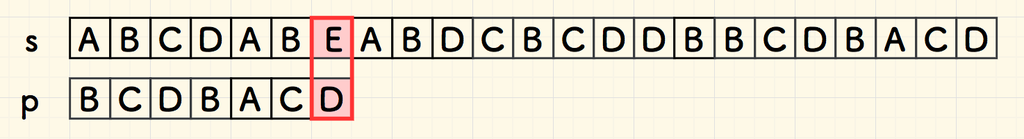

图 1.1 - 自右向左开始比对

第一次比对，即在字符 `E` 失配。 由于 `E` 不在子串 `p` 中，因此，可以直接把整个子串右移到其右边。

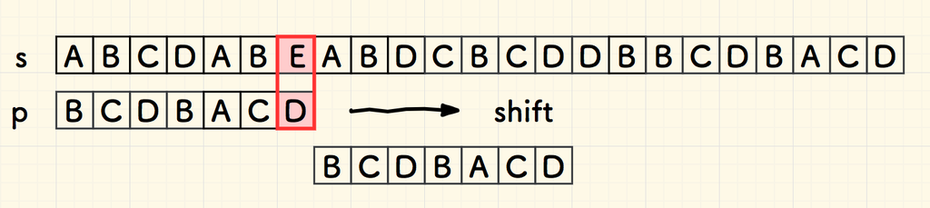

图 1.2 - 右移 p 到失配处右侧

继续向前匹配，此时在下图 1.3 中的红色部分失配。

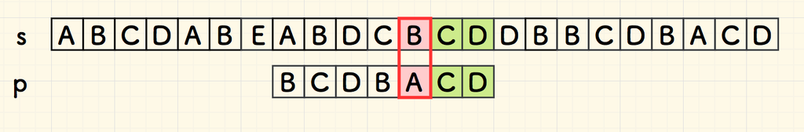

图 1.3 - 第二次失配的情况

但是，失配的 `B` 在子串 `p` 中，就在当前位置靠左一位的位置。 要想子串和主串在附近匹配成功，至少字符 `B` 要对的齐。 为了避免错过 `B` 的匹配，只能找到靠的最近的 `B` 对齐，也就是右移一位。

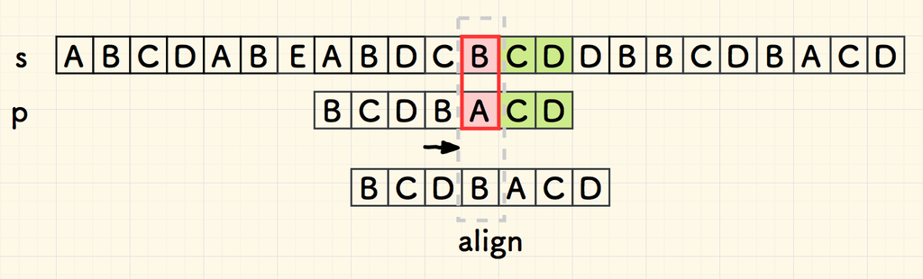

图 1.4 - 右移 p 和失配处对齐

继续向前匹配，在下图 1.5 中的红色部分失配。

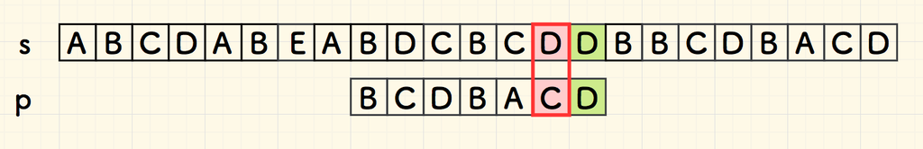

图 1.5 - 第三次失配的情况

沿用刚才上面的思路，失配的 `D` 也在子串中，右移 `p` ，让它们对齐：

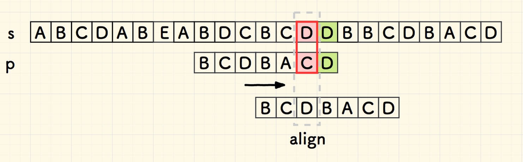

图 1.6 - 右移 p 和失配处对齐

总结出来规律了， 当失配的时候，右移子串，使得主串中失配的字符和子串中左边最近的相同字符对齐。如果不存在相同字符，就把整个子串右移到失配字符的右侧。

#### 坏字符的办法 ¶

常把失配处的字符叫做「坏字符」，每次右移，就要把 **坏字符和子串中最近的坏字符对齐**。

Boyer–Moore 算法和 [KMP 算法](https://writings.sh/post/algorithm-string-searching-kmp) 的思路类似，都是在失配处动脑筋，跳过无必要的比对，以加快搜索。

按这个思路，可以继续匹配下去，直到命中。

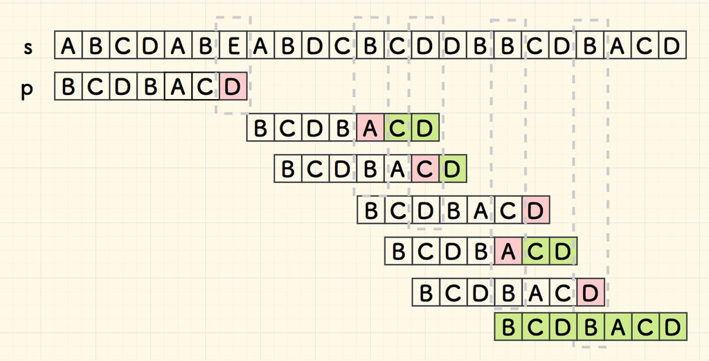

图 1.7 - 对齐「坏字符」的匹配办法

#### 好后缀的办法 ¶

上面坏字符的办法，还不够快。

比如下面这次对齐：

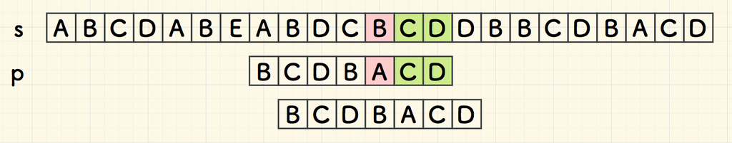

图 1.8 - 存在优化点的右移对齐

此时，已知的信息是，主串中有已经匹配好的 `CD` ，它同时也是子串 `p` 的后缀，常叫做「好后缀」。

要想子串在附近和主串匹配成功，它们的共同子串 `CD` 就要对的齐，所以，把对齐坏字符的办法应用到好后缀上， 找到最近的好后缀进行右移对齐。

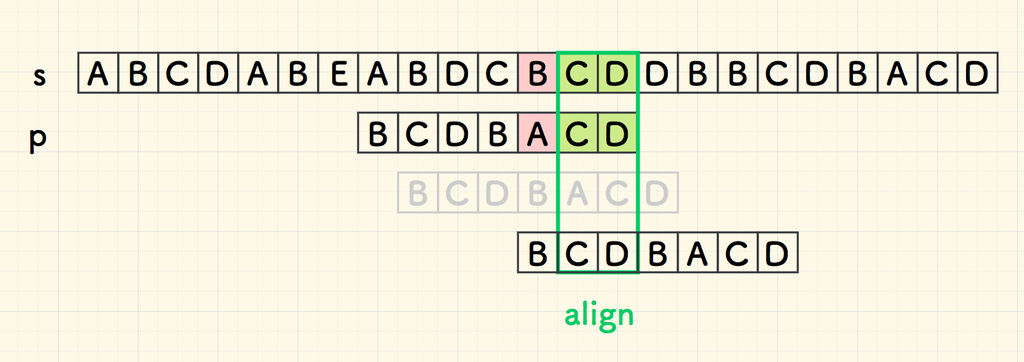

图 1.9 - 好后缀对齐的办法

如此一来，右移的更多了些。

好后缀的办法就是， **失配时，右移子串，使得主串中的好后缀和子串中左边最近的重复串对齐** 。 同样的，如果存在好后缀，而左边没有重复串时，那么直接把 `p` 右移到整个好后缀右边就好了。

综合两个办法后，整个搜索过程优化为下面的样子，总体上比只用坏字符的办法，少了两步。

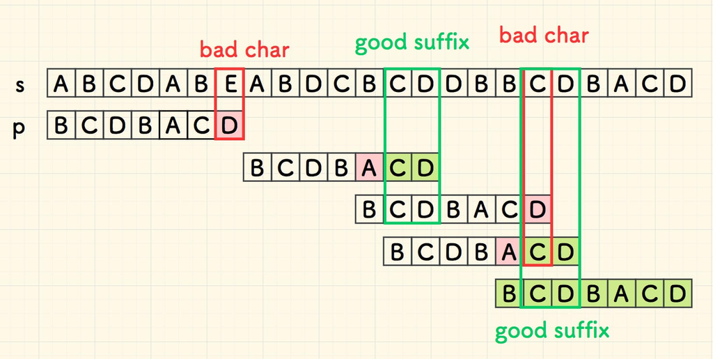

图 2.1 - 综合「坏字符」和「好后缀」办法的查找过程

### 编码思路 ¶

先考虑失配时迭代变量如何跳转的问题。

假设，主串和子串的迭代变量分别是 `i` 和 `j` 。

在失配时，显然， 子串回到尾巴，即 `j → m - 1` 。

关键是计算失配时 `i` 的迭代量。

##### 坏字符的办法

先考虑坏字符的办法。遇到一个坏字符的时候，假设子串中左边最近的坏字符对子串尾巴的距离是 `d`。

从下图可以推断出主串的迭代量就是 `d`：

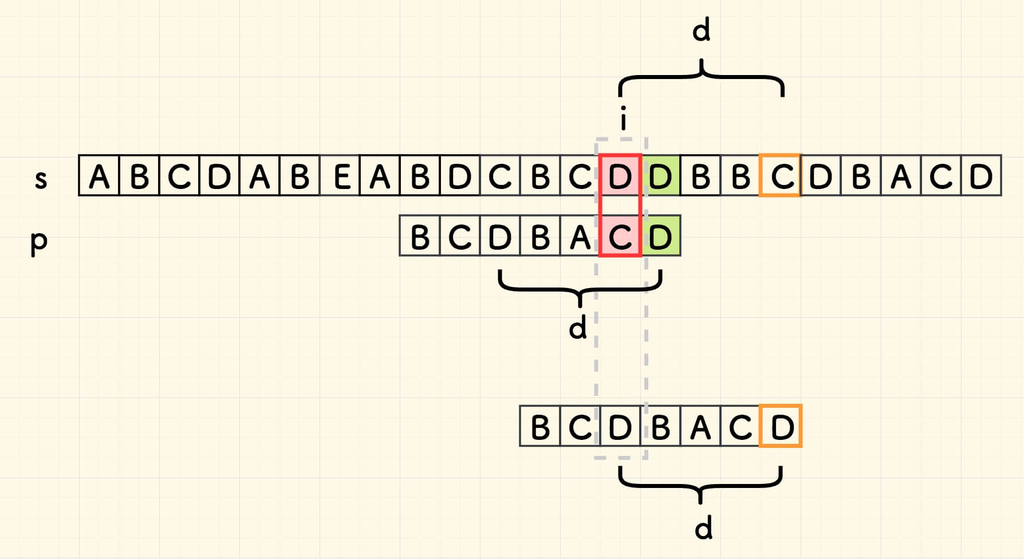

图 2.2 - 主串失配时的迭代量

特殊地，坏字符在子串左边不存在时，主串迭代的量应是子串长度 `m` ，则取 `d = m` 来满足。

##### 好后缀的办法

对于好后缀的办法，道理是相似的 。

把拿来对齐的左边的重复串叫做 `repeat`， 把对齐好后缀的过程，看作对齐 `repeat` 前面那个字符的过程，即可复用上面的思路。 如此一来，假设 `repeat` 前面字符到尾巴字符的距离是 `d` ，则失配的时候，主串的迭代量就是 `d`。

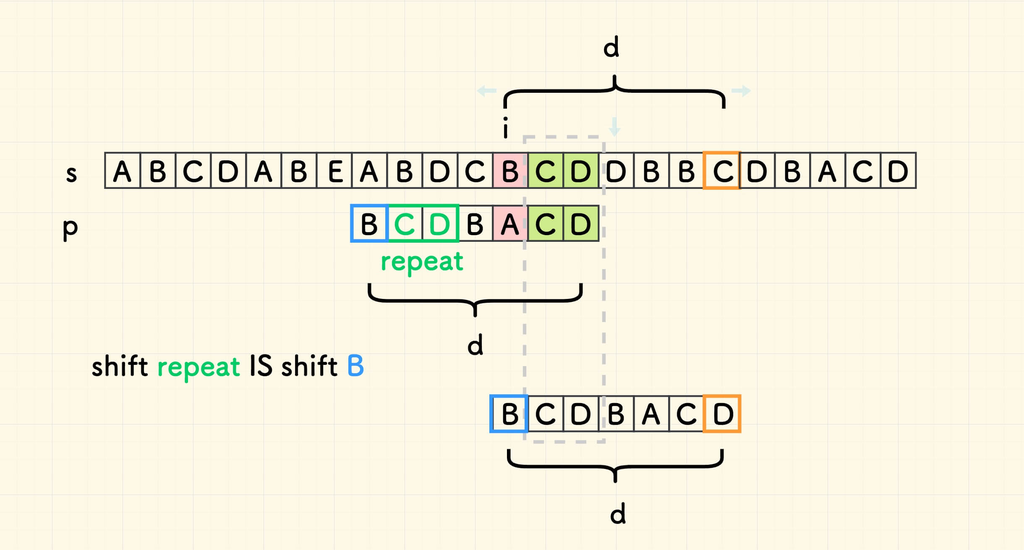

图 2.3 - 主串失配时的迭代量

进一步地，若假设重复串 `repeat` 的头部的位置是 `t` 的话， `d` 其实是 `m - t` 。

如果重复串 `repeat` 在 `p` 的开头，前面没有字符，此时主串的迭代量是 `m`，而 `t` 恰好是 `0` ，仍然满足 `d = m - t` 的关系。 下面的图 2.4 构造了这种情况 （为说明问题，对本文用例稍加改造）：

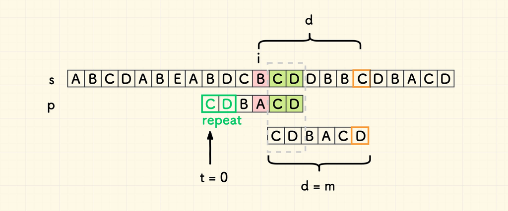

图 2.4 - 重复串 repeat 恰好在子串开头的情况

但是，如果重复串 `repeat` 在 `p` 的左边不存在，情况变得复杂起来，分情况讨论：

1. **好后缀部分匹配到了 `p` 的一个前缀**

   下图 2.5 构造了这一种情况，此时应该右移到对齐 「匹配到的部分」。

   在下图中需要对齐绿色的 `CD` 。 可以看到此时的主串迭代量 `d` 比搜索串的长度 `m` 要大。

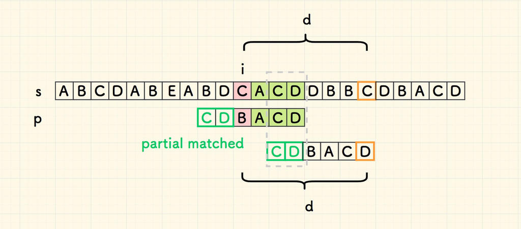

   图 2.5 - 好后缀部分匹配到子串的前缀的情况

   为了进一步找出计算公式，可以虚假地构造一部分前缀 `fake`，即可套用 完全匹配到开头 的情况。

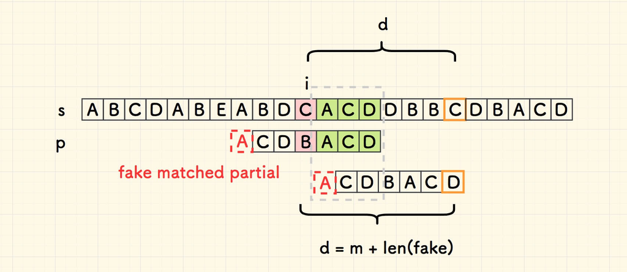

   图 2.6 - 构造虚拟前缀来套用完全匹配的情况

   可以看到， `d = m + len(fake)` ，实际即是 `m + len(suffix) - len(prefix)`。
2. **好后缀在 `p` 的左边完全没有匹配上**

   主串迭代量 `d` 则是 `m + 好后缀长度`。

   下图 2.7 构造了这一种情况。可以看到，这是第一个情况，即 部分匹配前缀 的一种特例。

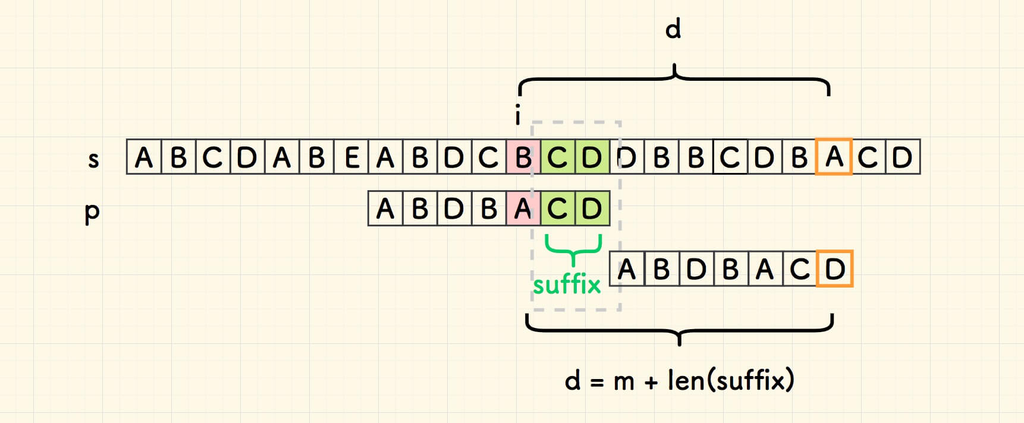

   图 2.7 - 好后缀和搜索串完全失配的情况

总而言之，好后缀的办法，分为两种情况：

1. **好后缀在左边**：`d = m - t`
2. **好后缀不在左边**：`d = m + len(suffix) - len(prefix)`

事实上，无论坏字符的办法、还是好后缀的办法， **失配情况下，主串的迭代量是与主串无关的** 。

#### 坏字符表 ¶

前面所说的 `d` 预处理成为一个表格，包括两个维度：主串中的坏字符 和 子串失配的位置，如下图所示 （问号表示其他字符）：

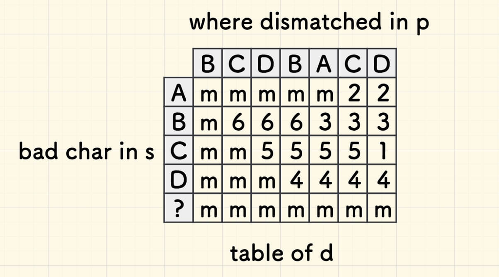

图 3.1 - 坏字符表格

假设字符集的大小是 `S` （一般取 [ASCII 表](https://www.ascii-code.com/) 的大小 `256`） 。 事实上，此表格可以用归纳的方法，以 `O(S * m)` 的线性时间复杂度计算得出。

其方法是， 假设当前格子对应的子串失配的字符是 `p[k]` ，自上而下，自左而右进行填表：

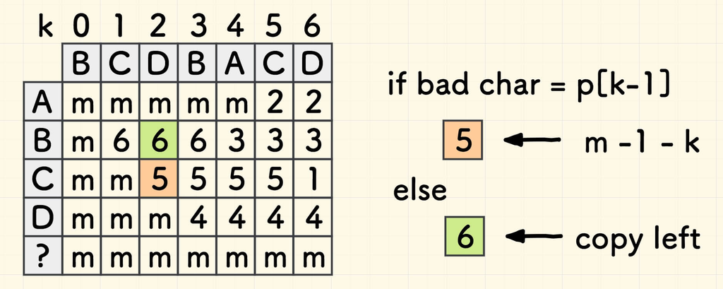

图 3.2 - 坏字符表格的填表方式

这个表格的空间占用则是 `O(S * m)` 。 实际中，大多数的编码实现都只取最后一列，即只采用一个一维表格，其具有常数大小的空间占用。 例如，[Golang 官方的字符串搜索](https://golang.org/src/strings/search.go) 采用 Boyer-Moore 算法，构建的是一维坏字符表。

另外，[Boyer-Moore 算法 - 维基百科](https://en.wikipedia.org/wiki/Boyer%E2%80%93Moore_string-search_algorithm#Implementations) 中也确有指出 [创建二维坏字符表的方法](https://en.wikipedia.org/wiki/Boyer%E2%80%93Moore_string-search_algorithm#The_bad_character_rule)， 并且有给出使用二维坏字符表的 Python 实现。

采用一维坏字符表时，表格含义即退化为：**坏字符在子串中最右侧出现的位置，距离尾巴字符的距离** 。

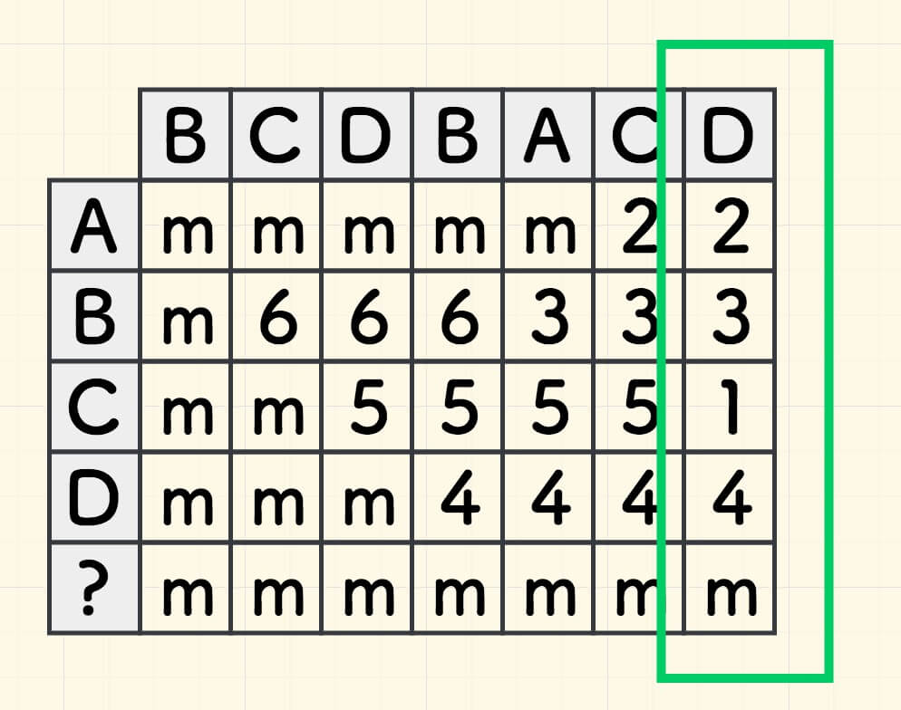

图 3.3 - 坏字符表格的退化

同时，构建坏字符表格的方法也会更简单：

- 初始化一维表格 `table` 的每一项是 `m` 。
- 假设 `p` 的尾巴字符的位置是 `last = m-1` ：

  对尾巴左边的每个字符 `char = p[k]` ，不断覆盖 `table[char] = last - k` 即可。

  上面注意 `k = 0..(last - 1)` ，尾巴字符左边的字符才有可能成为坏字符的对齐目标。

一维的坏字符表格如下所示：

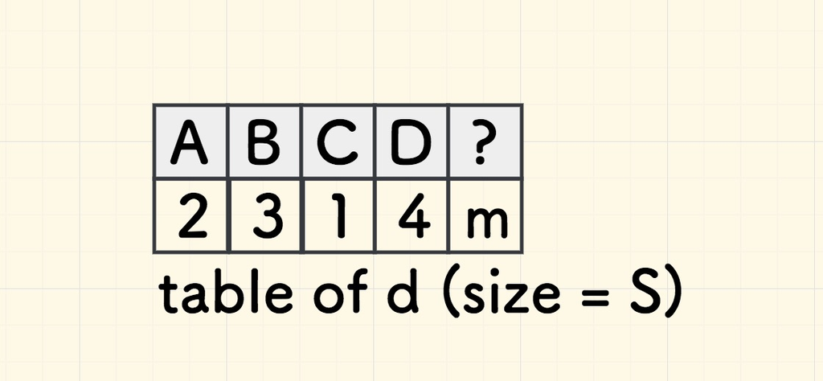

图 3.4 - 一维的坏字符表格

**C 语言实现 - 填写坏字符表**

```c
// ComputeBadCharTable 计算一维坏字符表
void ComputeBadCharTable(char *p, int m, int table[]) {
    // 初始化每一个字符的坏字符表值为 m
    for (int i = 0; i < ALPHABET_SIZE; i++) {
        table[i] = m;
    }
    // 对尾巴左边的字符，不断覆盖它到尾巴 last 的距离
    // 坏字符的对齐目标绝不在尾巴字符上。
    int last = m - 1;
    for (int i = 0; i < last; i++) {
        char ch = p[i];
        table[ch] = last - i;
    }
}
```

#### 好后缀表 ¶

好后缀表的构造一般被认为是 Boyer-Moore 算法中最难的部分。

前面已经分析 好后缀方法中的 `d` 存在两种情况。

明确现在的问题，对于搜索串 `p` 的所有后缀 `suffix(k)` ，找出对应的 `d`，其中 `k` 是失配的位置。

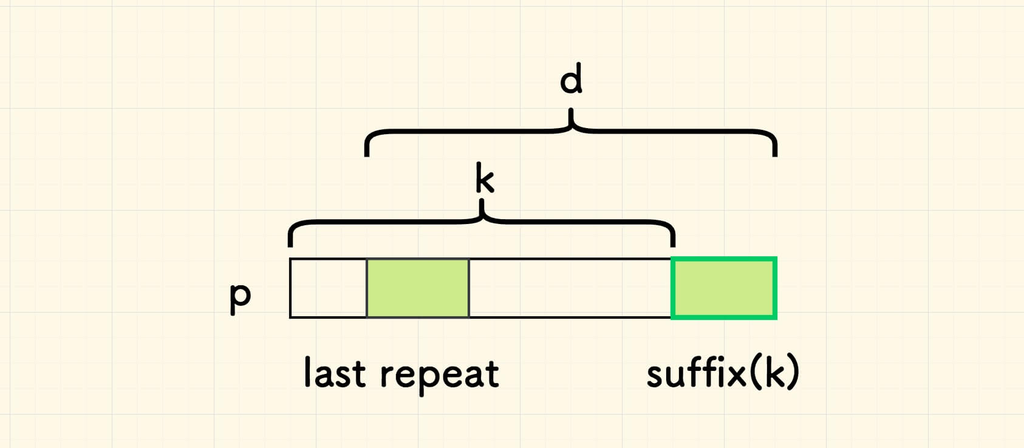

假设存放 `d` 的一维数组是 `table` ，考虑此表格如何填写。

参考 前面的分析 ， 共有两种情况，分两次填表。

先处理第二种情况的填表过程，即 好后缀不在左边的情况。

原因在于，`table` 的意义是失配时，主串迭代的多少。 第二种情况的值更大。 先填写更大的，再覆盖以小的， 这样才不至于错过小迭代量的匹配点。

##### 好后缀不在左边的情况

为方便说明，本部分的搜索串的示例调整为 `DDDBDDD` 。

参考 前面的分析 ，此情况下的 `d = m + len(suffix) - len(prefix)` 。

举例来说，当好后缀为 `BDDD` 的时候，`d` 的求值如下图所示：

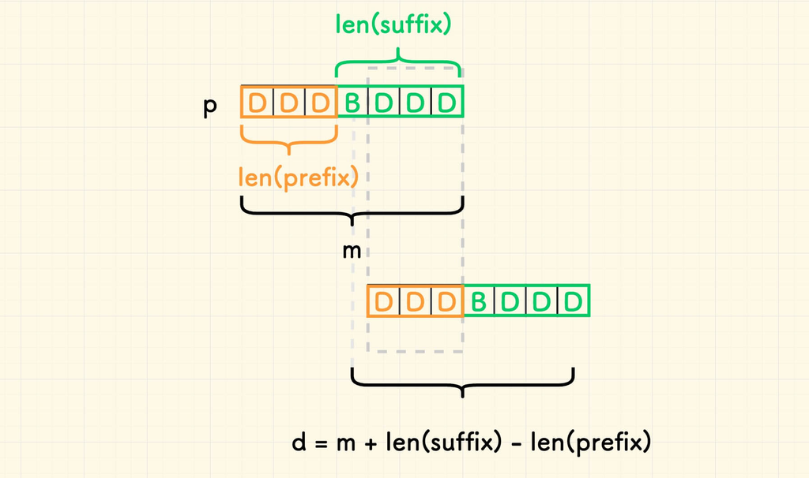

问题是：如何找到搜索串的每一个后缀的部分匹配前缀 ？

下图中，`suffix(k)` 表示在 `k` 处失配时的好后缀，黄色框表示其对应的部分匹配前缀， 右边依次列出前缀的长度：

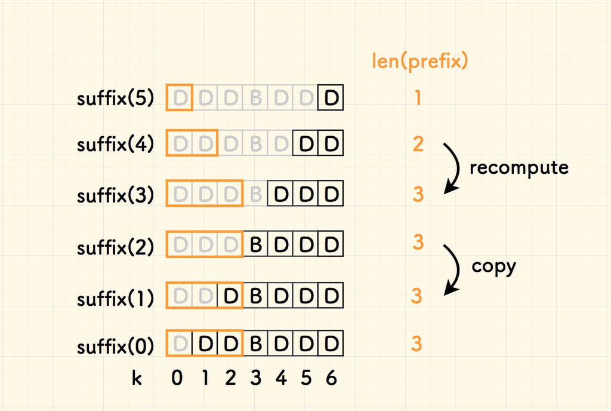

前缀长度的变化是有规律的，从上而下填写：

- 如果后缀是一个前缀，计算 `len(prefix) = len(suffix)` ，并记录为 `last_prefix_length` 。
- 否则，沿用上一次的计算结果： `len(prefix) = last_prefix_length` 。

是否和 [KMP 算法的 next 数组计算方式](https://writings.sh/post/algorithm-string-searching-kmp#%E5%A4%B4%E5%B0%BE%E5%85%AC%E5%85%B1%E9%95%BF%E5%BA%A6) 类似呢。

`len(prefix)` 的计算清楚之后，此情况的填表过程即得到解决。

**C 语言实现 - 填写好后缀表 - 好后缀不在搜索串的左边的情况**

```c
// ComputeGoodSuffixTableCaseNotInLeft
// 填写好后缀表，处理情况：好后缀不在搜索串的左边的情况
void ComputeGoodSuffixTableCaseNotInLeft(char *p, int m, int table[]) {
    int last_prefix_length = 0;

    // 失配位置在 m - 1 时，好后缀无意义，设为跳动最少 1
    table[m - 1] = 1;

    // i 表示后缀的起始位置
    for (int i = m - 1; i > 0; i--) {
        // k 表示失配的位置
        int k = i - 1;
        int suffix_length = m - i;
        char *suffix = p + i;
        int prefix_length = 0;

        if (strncmp(p, suffix, suffix_length) == 0) {
            // 如果后缀是一个前缀
            prefix_length = suffix_length;
            last_prefix_length = prefix_length;
        } else {
            // 否则，沿用上次结果
            prefix_length = last_prefix_length;
        }

        // 计算 d
        table[k] = m + suffix_length - prefix_length;
    }
}
```

##### 好后缀在左边的情况

为方便说明，本部分的搜索串的示例调整为 `DCDBCDACD` 。

参考 前面的分析 ，此情况下的 `d = m - t` ， 如何计算 `t` 取决于如何找到左边**最右的**重复串。

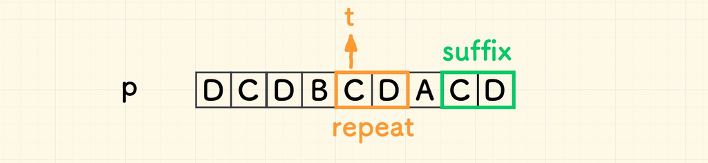

引入一个概念：**最长公共后缀** ，如图所示：

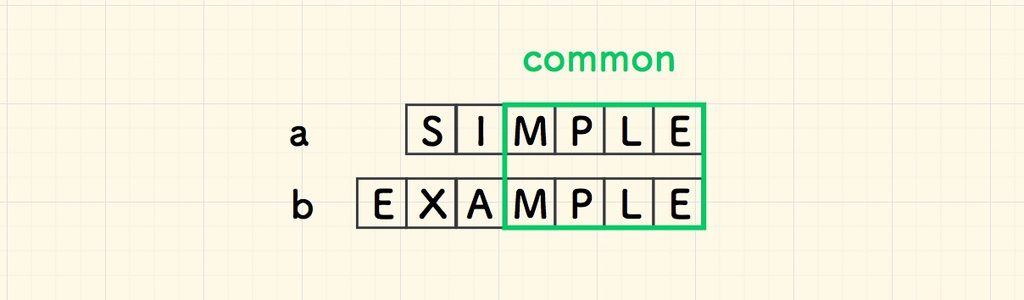

**C 语言实现 - 最长公共后缀长度**

```c
// GetLongestCommonSuffixLength 返回字符串 a 和 b 的最长公共后缀长度。
// 比如 'simple' 和 'example' 的最长公共后缀是 'mple' ，长度是 4.
int GetLongestCommonSuffixLength(char *a, int a_length, char *b, int b_length) {
    int i = 0;
    for (i = 0; i < a_length && i < b_length; i++) {
        if (a[a_length - 1 - i] != b[b_length - 1 - i]) {
            break;
        }
    }
    return i;
}
```

**如果左边存在重复串，那么它是一个前缀 和 `p` 的最长公共后缀** 。

下图中，两个前缀串和 `p` 的最长公共后缀相同，取长的那个。 这样才能找到 **最右的** 重复串。

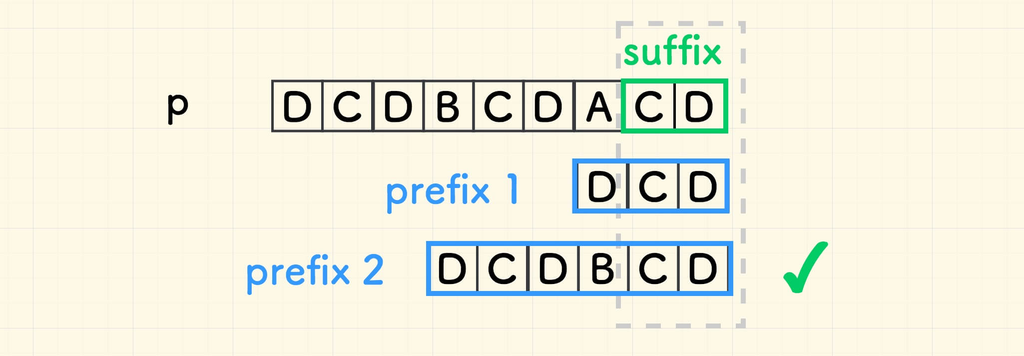

也就是，前缀要从短往长去找，用长的去覆盖短的计算结果 。

如果前缀以 `e` 下标结尾， 显然 `t = e + 1 - len(suffix)` 。

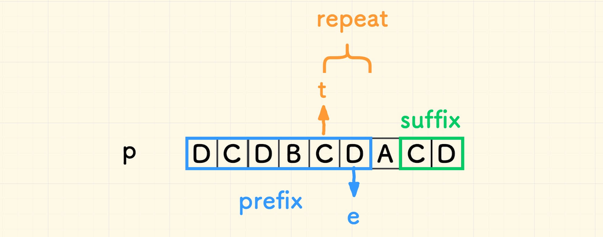

至此，思路如下：

- 对 `p` 的每个前缀，计算它和 `p` 的最长公共后缀，设其长度 `len`
- 即确定了长度为 `len` 的后缀，相应的 `t` 亦可得出。
- 长的前缀的计算结果覆盖短的。

**进一步的说明**

为方便说明，将搜索串 `p` 的例子调整为 `ACDBCDABCD` 。

后缀 `CD` 对应的前缀则是：

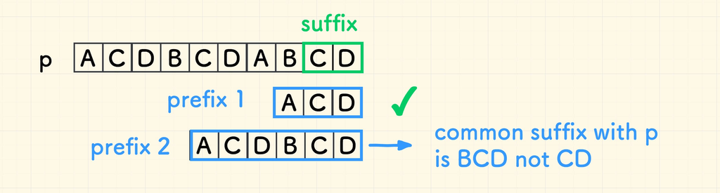

注意的是，此情况下重复串的位置，在 `prefix1` 结尾。

并非巧合，重复串和好后缀左边的字符必然不同， 否则右移后坏字符仍然失配。

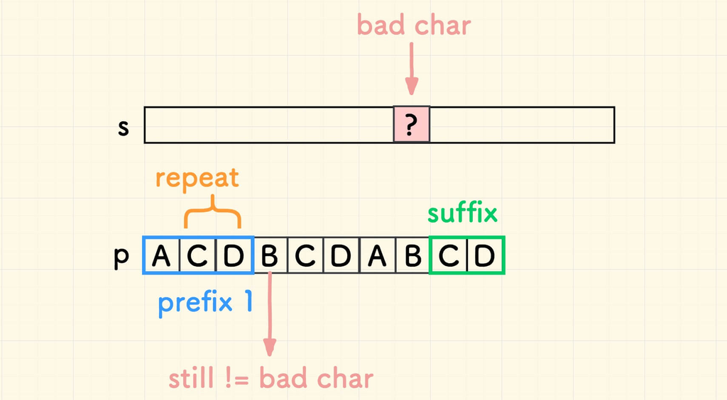

**C 语言实现 - 填写好后缀表 - 好后缀在搜索串的左边的情况**

```c
// ComputeGoodSuffixTableCaseInLeft
// 填写好后缀表，处理情况：好后缀在搜索串的左边的情况
void ComputeGoodSuffixTableCaseInLeft(char *p, int m, int table[]) {
    // e 表示对应的前缀的结尾位置
    for (int e = 0; e < m - 1; e++) {
        // 前缀字符串
        char *prefix = p + e;
        // 前缀的长度
        int prefix_length = e + 1;
        // 最长公共后缀的长度，即好后缀的长度
        int suffix_length =
            GetLongestCommonSuffixLength(p, m, p, prefix_length);

        if (suffix_length > 0) {
            // 好后缀长度 > 0 才有意义
            // t 是重复串的起始位置
            int t = e + 1 - suffix_length;
            // 失配字符的位置
            int k = m - 1 - suffix_length;
            // 填表，覆盖
            table[k] = m - t;
        }
    }
}
```

**C 语言实现 - 填写好后缀表 - 综合两种情况**

```c
// ComputeGoodSuffixTable 计算好后缀表的方法
void ComputeGoodSuffixTable(char *p, int m, int table[]) {
    // 先处理第二种情况：好后缀在搜索串左边不存在的情况
    // 即好后缀和搜索串部分匹配或者完全不匹配的情况
    ComputeGoodSuffixTableCaseNotInLeft(p, m, table);
    // 再处理第一种情况：好后缀在搜索串左边存在的情况
    ComputeGoodSuffixTableCaseInLeft(p, m, table);
}
```

### 查找过程 ¶

可以看到，**坏字符表和好后缀表只和搜索串有关，可以提前生成** 。

至此，已可以完成整个 Boyer-Moore 算法：

- 对搜索串，填写坏字符表和好后缀表
- 先对齐主串和搜索串。
- 自右向左匹配。
- 失配时，挑选两张表中最大的跳转量，作为主串的迭代量。

**C 语言实现 - BoyerMoore 查找**

```c
#define max(a, b) ((a < b) ? b : a)

// BoyerMoore 从长度为 n 的字符串 s 中查找长度为 m 的字符串 p ， 返回其位置.
// 找不到则返回 -1
int BoyerMoore(char *s, int n, char *p, int m) {
    int bad_char_table[ALPHABET_SIZE];
    int good_suffix_table[m];

    ComputeBadCharTable(p, m, bad_char_table);
    ComputeGoodSuffixTable(p, m, good_suffix_table);

    // 初始化，i, j 右对齐
    int i = m - 1;

    while (i < n) {
        int j = m - 1;

        // 自右向左匹配
        while (j >= 0 && p[j] == s[i]) {
            j--;
            i--;
        }

        if (j < 0) {
            // 命中, 返回起始位置
            return i + 1;
        }

        // 失配时，跳转的多少，选取坏字符表和好后缀表中最大的跳转量
        i += max(bad_char_table[s[i]], good_suffix_table[j]);
    }

    return -1;
}
```

此外，Go 语言的实现可以参考官方的 search.go 。

### 复杂度分析 ¶

好后缀表在两种情况下的构建的时间复杂度均为 `O(m^2)` ，不过一般情况下搜索串的长度相对主串会很小， [Golang 的官方实现](https://golang.org/src/strings/search.go) 对好后缀表的构建方法亦和本文的一致。

事实上， [Boyer-Moore 算法 - 维基百科](https://en.wikipedia.org/wiki/Boyer%E2%80%93Moore_string-search_algorithm#The_good_suffix_rule) 告诉我们，好后缀表可以在线性时间内构建，可以参考其给出的 [Python 实现](https://en.wikipedia.org/wiki/Boyer%E2%80%93Moore_string-search_algorithm#Implementations) ， 其中采用的是 Z-算法。

查找过程的时间复杂度是 `O(m * n)` ，其中最好情形如下图所示，时间复杂度是 `O(n / m)` ：

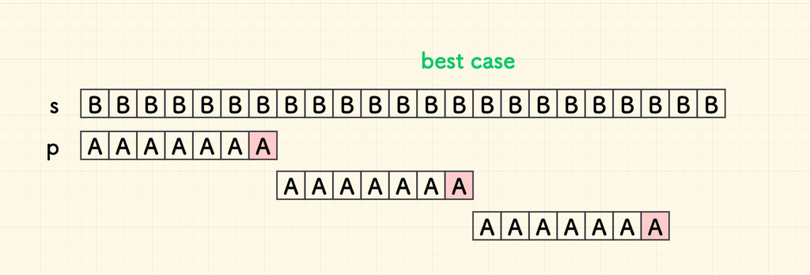

Boyer-Moore 算法的最好情形

最坏情形的时间复杂度是 `O(m * n)` ，退化成为简易的二次循环匹配：

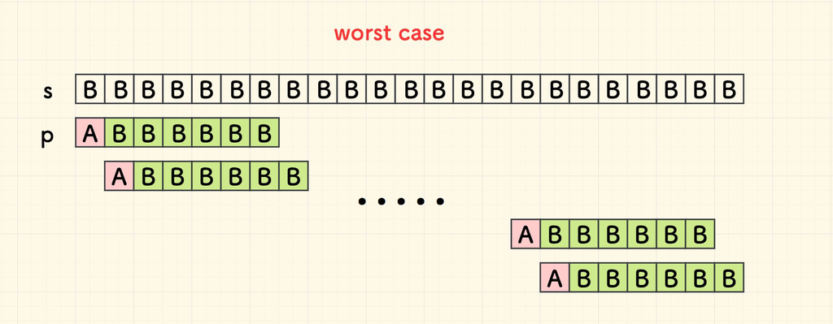

Boyer-Moore 算法的最坏情形

### 结语 ¶

Boyer-Moore 的坏字符办法和好后缀办法，可以综合使用，也可以单独使用一种，其中坏字符的办法实现更简单一些。

事实上，我认为 Boyer-Moore 算法远不如 [KMP 算法](https://writings.sh/post/algorithm-string-searching-kmp) 干练精巧，其主体查找过程虽然更容易理解，但是两种表格的计算，尤其是好后缀表的构建， 确是相对复杂的。

相关阅读：[字符串匹配 - KMP 算法](https://writings.sh/post/algorithm-string-searching-kmp)

（完）

王超 · 2021 年 2 月

[原创文章，未经允许，不得转载](https://writings.sh/about#copyright)